# Instruções de preparação do ambiente

Verifique se o python está instalado no seu sistema acessando um terminal de linha de comando.

## Windows

Pressione as teclas WIN+R e execute o aplicativo "cmd", na janela do terminal, digite "python --version".

A partir do Windows 10, caso o python não esteja instalado, o instalador do loja de aplicativos será iniciado para baixar a versão disponível para o sistema. Caso não inicie, baixe a versão compatível em: https://www.python.org/downloads/windows/

## Linux

Na maioria das distribuições Linux, o python está instalado por padrão. Abra um terminal de linha de comando e execute o comando "python --version"

## Instalando as dependências do projeto

Esse "notebook" utiliza as libs "matplotlib" e "numpy" para algumas funções matemáticas e de visualização das imagens. A instalação destas bibliotecas pode ser feita com o aplicativo de instalações de pacote do python, "pip".

Abra o terminal de linha de comando e digite:

> pip install matplotlib numpy

Os comandos para instalação estão na próxima célula. Basta executar

## VSCode ou Jupyter Notebook

Para edição e execução deste notebook, pode ser utilizado o VSCode com a extensão Jupyter ou utilizando o próprio jupyter notebook diretamente. Prefira o uso do VSCode com a extensão Jupyter, por ser mais simples de configurar.

Para instalar o jupyter, utilize o aplicativo de instalação de pacotes "pip"

> pip install jupyter jupyter notebook

## Ambiente virtual Venv (opcional)

Para que você instale uma versão específica do python, juntamente como bibliotecas e ferramentas específicas para um projeto sem que isso afete a configuração geral do seu sistema operacional, você pode usar um ambiente virtual, mais informações em: https://dev.to/franciscojdsjr/guia-completo-para-usar-o-virtual-environment-venv-no-python-57bo

```python
%pip install matplotlib numpy
```

```python
import copy
import os
import matplotlib.pyplot as plt
import numpy as np
```

```python
def get_celeb_files():
    """
    Carrega o dataset de imagens de celebridades no diretório
    img_align_celeba
    Retorna os nomes de arquivos
    """

    files = [os.path.join('img_align_celeba', file_i)
             for file_i in os.listdir('img_align_celeba')
             if '.jpg' in file_i]
    return files

def get_celeb_imgs():
    """
    Carrega as imagens de celebridades guardados no diretório
    Retorna as imagens em um array
    """
    return [plt.imread(f_i) for f_i in get_celeb_files()]
```

```python
files = get_celeb_files()
```

```python
img = plt.imread(files[0])
```

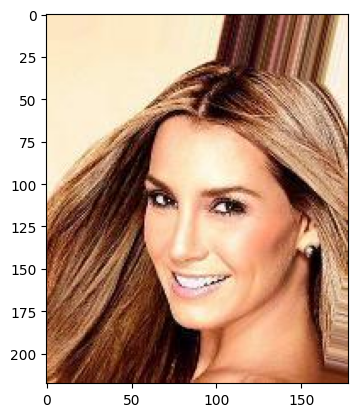

```python
plt.imshow(img)
```

```python
for j in img[:,:,0]:
    for i in j:
        print(i, end=" ")
    print("")
```

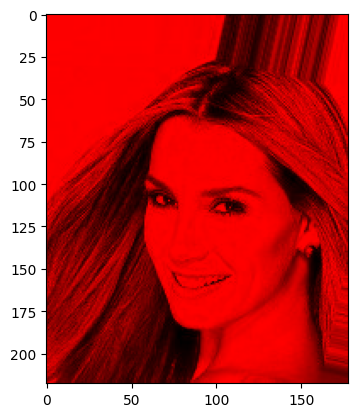

```python
rimg=copy.deepcopy(img);
rimg[:,:,1]=0
rimg[:,:,2]=0
plt.imshow(rimg)
```

```python
print(rimg.shape)
```

```
(218, 178, 3)
```

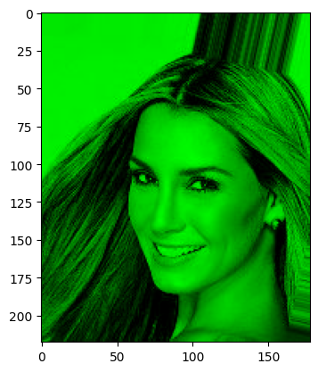

```python
gimg=copy.deepcopy(img);
gimg[:,:,0]=0
gimg[:,:,2]=0
plt.imshow(gimg)
```

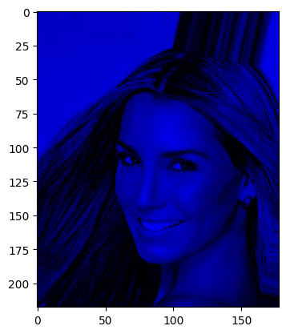

```python
bimg=copy.deepcopy(img);
bimg[:,:,0]=0
bimg[:,:,1]=0
plt.imshow(bimg)
```

```python
imagens = get_celeb_imgs()
```

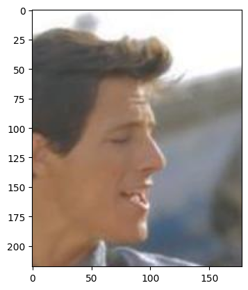

```python
plt.imshow(imagens[2])
```

```python
dados = np.array(imagens)
```

```python
dados.shape
```

```
(100, 218, 178, 3)
```

```python
mean_img = np.mean(dados,axis=0)
```

```python
max_img = np.max(dados,axis=0)
```

```python
min_img = np.min(dados,axis=0)
```

```python
std_img = np.std(dados,axis=0)
```

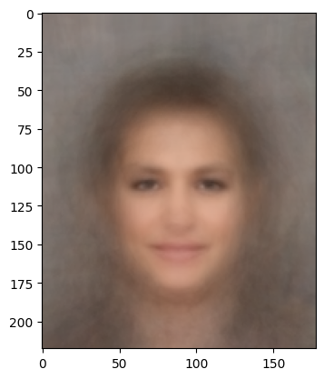

```python
plt.imshow(mean_img.astype(np.uint8))
```

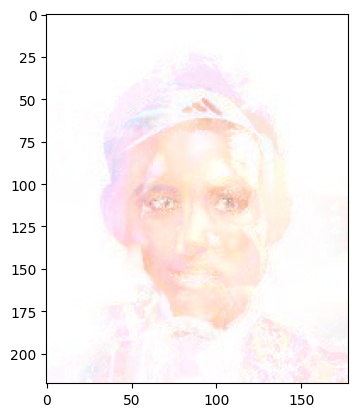

```python
plt.imshow(max_img.astype(np.uint8))
```

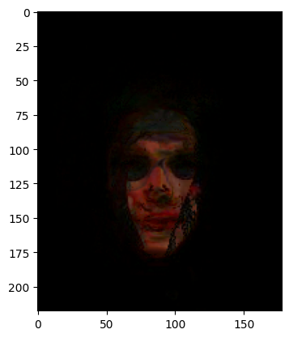

```python
plt.imshow(min_img.astype(np.uint8))
```

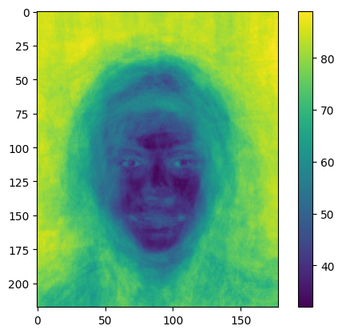

```python
plt.imshow(np.mean(std_img,axis=2).astype(np.uint8))
plt.colorbar()
```